# Econometrics

TA Session 7

Lucia Sauer

*Barcelona School of Economics*

lucia.sauer@bse.eu

2026-11-18

## Planification — 2° Part

**TA6 — RCTs** ✓

**TA7 — Matching** ← today

**TA8 — Instrumental Variables**  
📆 Hand in Assignment 6 by **18th Nov**

**TA9 — Regression Discontinuity**  
📆 Hand in Assignment 7 by **27th Nov**

**TA10 — Difference-in-Differences**  
📆 Hand in Assignment 8 by **2nd Dec**

## Today

1. **Observational data** — was the treatment randomly assigned?
2. **Matching on covariates** — nearest neighbour, exact matching
3. **The propensity score** — common support, balancing property, NN / radius / kernel
4. **Back to job training** — which matching method wins, and did it recover the experiment?

💻 Stata: **TA7.do** (data `nsw_cps.dta`) · 📓 Python version: **TA7.ipynb**

# 1 · Observational data

## Did a job-training program raise earnings?

**National Supported Work (NSW):** a 1970s US program that gave disadvantaged workers (ex-offenders, ex-addicts, long-term unemployed) 9–18 months of subsidized work experience. We want its effect on **earnings in 1978**.

185

Participants

D = 1 · mean 1978 earnings $6,349

15,992

Non-participants

US adults from a survey (CPS) · $14,847

Naive comparison: $\bar Y_1 - \bar Y_0 = 6{,}349 - 14{,}847 = -8{,}498$ dollars. Did training really **cut** earnings by $8,498? Or are participants and non-participants simply **different people**?

This is **observational data**: nobody flipped a coin. People ended up in the program (or not) for reasons we don’t control. First question, as in TA6: **do the two groups look alike before treatment?**

## Was the treatment randomly assigned? A balance check

For each pre-treatment covariate $X_k$: $\;H_0: E[X_k \mid D = 1] = E[X_k \mid D = 0]$, Welch $t$-test (as in TA6). If $D$ were random, we would reject only ~5% of the time.

| Covariate | Participants | Non-participants | Difference | p-value |
| --- | --- | --- | --- | --- |
| Age | 25.82 | 33.23 | -7.41 | < 0.001 |
| Years of education | 10.35 | 12.03 | -1.68 | < 0.001 |
| Black | 0.84 | 0.07 | 0.77 | < 0.001 |
| Hispanic | 0.06 | 0.07 | -0.01 | 0.475 |
| Married | 0.19 | 0.71 | -0.52 | < 0.001 |
| No high-school degree | 0.71 | 0.30 | 0.41 | < 0.001 |
| Earnings 1974 ($) | 2,096 | 14,017 | -11,921 | < 0.001 |
| Earnings 1975 ($) | 1,532 | 13,651 | -12,119 | < 0.001 |
| Unemployed 1974 | 0.71 | 0.12 | 0.59 | < 0.001 |
| Unemployed 1975 | 0.60 | 0.11 | 0.49 | < 0.001 |

**9 of 10** p-values are below 0.05 ⇒ the groups are **not** comparable: clear signs of **non-random** assignment. Participants are younger, less educated, mostly Black, rarely married, and earned about 1/7 of what non-participants earned in 1974–75. And these same variables also determine 1978 earnings ⇒ they are **confounders**.

## Without a coin flip, who gets treated is not random

In TA6 randomization made $\;E[Y \mid D = 1] - E[Y \mid D = 0] = \text{ATT}$. Without it:

$$\underbrace{E[Y \mid D = 1] - E[Y \mid D = 0]}_{\text{naive comparison}} \;=\; \underbrace{E[Y(1) - Y(0) \mid D = 1]}_{\text{ATT}} \;+\; \underbrace{E[Y(0) \mid D = 1] - E[Y(0) \mid D = 0]}_{\text{selection bias}}$$

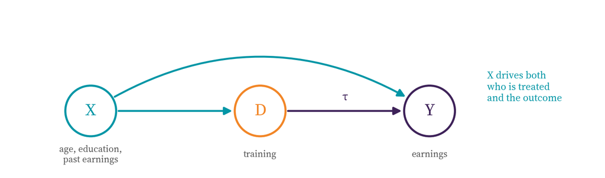

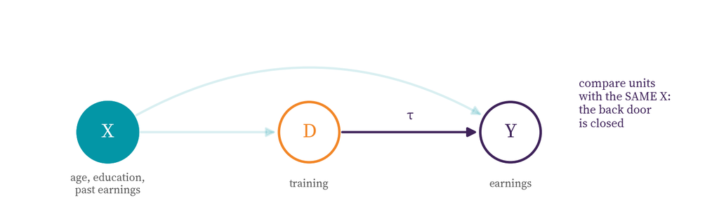

**Idea of matching:** compare treated and untreated units **that look the same in $X$**. Within such a group, who got treated is “as good as random”.

## Two assumptions

**1 · Conditional independence (CIA)**

$$\big(Y(1), Y(0)\big) \perp\!\!\!\perp D \mid X$$

Once we compare units with the same $X$, treatment is as good as random. **Untestable**: we must observe **every** confounder (“selection on observables”).

**2 · Overlap (common support)**

$$0 < P(D = 1 \mid X) < 1$$

For every $X$ there are both treated **and** untreated units: someone to compare with. **Testable**: we look at the data.

For the ATT we only need to impute $E[Y(0) \mid D = 1]$:

$$\text{ATT} \;=\; E[Y \mid D = 1] \;-\; E\big[\,\underbrace{E[Y \mid X, D = 0]}_{\text{untreated with the same } X} \;\big|\; D = 1\big]$$

❗ Matching is **not** a design like an RCT: it is only as good as the $X$’s you observe. It cannot fix confounding by **unobserved** variables.

# 2 · Matching

## Matching = imputing the missing counterfactual

A toy version of our question ($Y$ = earnings, thousand $). For each **treated** unit, find the **untreated** unit with the most similar $X$ and use its $Y$ as the missing $Y_i(0)$.

| Unit | D | Age | Educ. | Y(1) | Y(0) | Matched to | τ̂ᵢ = Y(1) − Y(0) |
| --- | --- | --- | --- | --- | --- | --- | --- |
| A | 1 | 24 | 10 | **9.8** | ?8.0 | #1 | +1.8 |
| B | 1 | 31 | 9 | **7.1** | ?6.0 | #3 | +1.1 |
| C | 1 | 22 | 12 | **11.5** | ?9.9 | #4 | +1.6 |
| D | 1 | 28 | 11 | **8.4** | ?7.0 | #6 | +1.4 |
| #1 | 0 | 25 | 10 | ? | **8.0** |  |  |
| #2 | 0 | 45 | 16 | ? | **21.3** |  |  |
| #3 | 0 | 30 | 9 | ? | **6.0** |  |  |
| #4 | 0 | 23 | 12 | ? | **9.9** |  |  |
| #5 | 0 | 52 | 13 | ? | **17.5** |  |  |
| #6 | 0 | 29 | 11 | ? | **7.0** |  |  |

$$\widehat{\text{ATT}} = \frac{1}{N_1}\sum_{i:\,D_i = 1} \big(Y_i - Y_{j(i)}\big) = \mathbf{+1.48}$$

Naive: $\bar Y_1 - \bar Y_0 = 9.20 - 11.62 = \mathbf{-2.42}$, because the untreated #2 and #5 are older and more educated: not comparable.

## Building intuition: two covariates

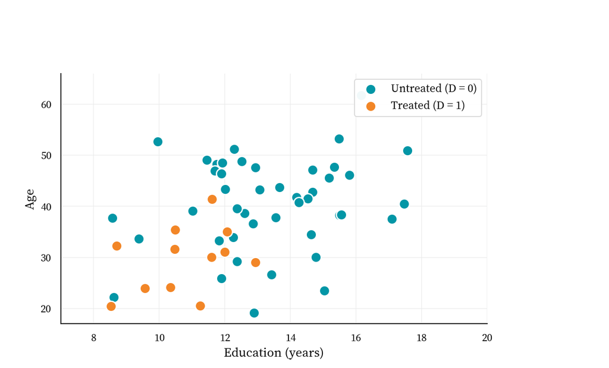

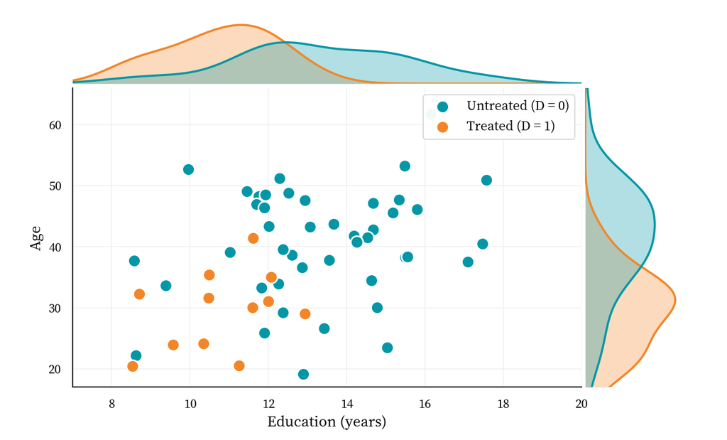

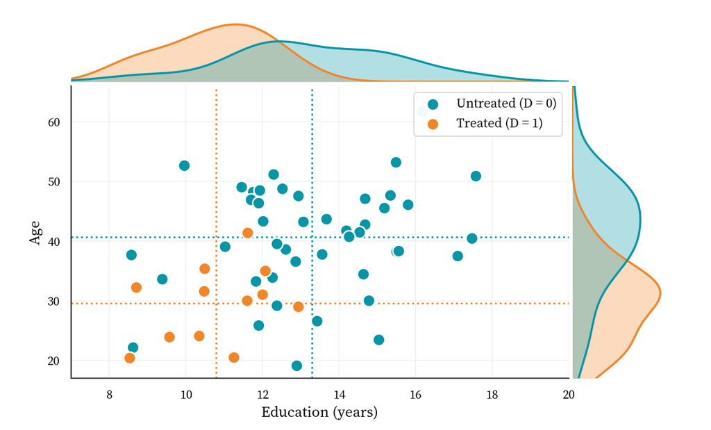

1. Two covariates, education and age: each dot is one person.
2. Their distributions (top: education, right: age) **differ**: treated are younger and less educated.
3. So do the means (dotted lines). Comparing all of them is comparing apples and oranges.

## Nearest-neighbour matching

Distance between treated $i$ and untreated $j$ (Mahalanobis, scale-free): $\;d(i,j) = \sqrt{(X_i - X_j)'\,S^{-1}\,(X_i - X_j)}$, with $S$ the covariance matrix of $X$.

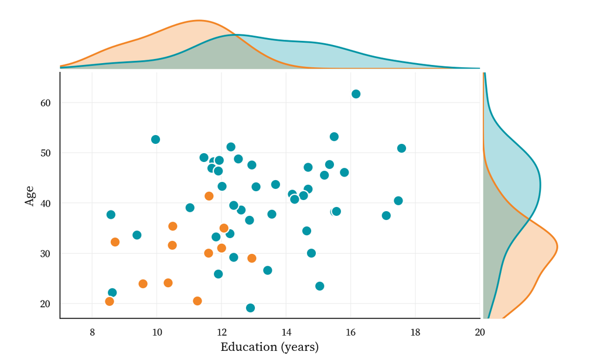

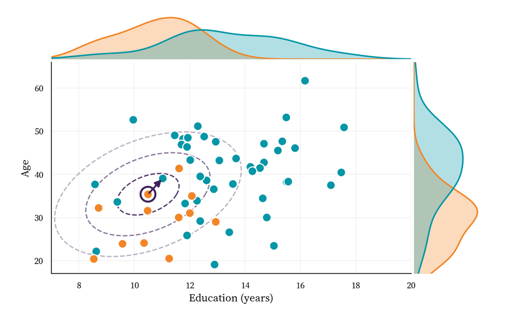

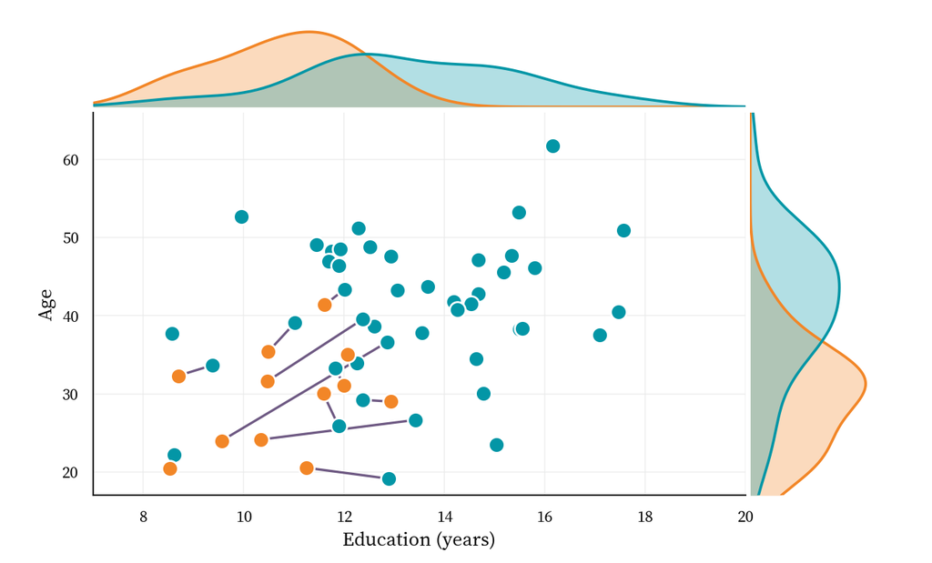

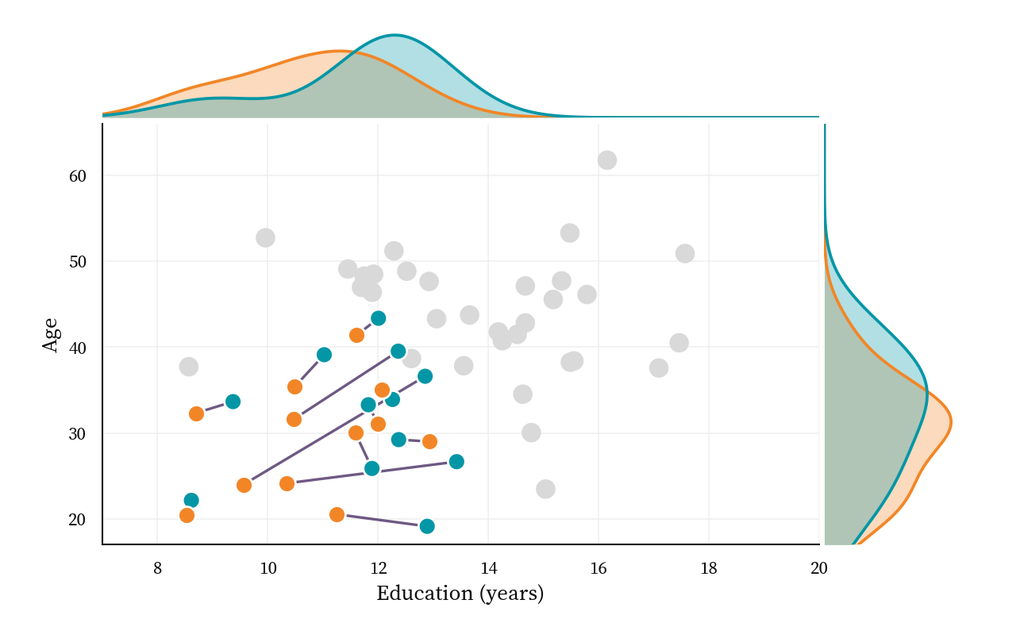

Nearest-neighbour matching

1. Start from all treated and untreated units.
2. Take one treated unit and find its **nearest** untreated neighbour (dashed ellipses: points at the same distance).
3. Repeat for every treated unit: closest pairs first, each untreated used once (no replacement).
4. Drop the untreated units that were not used: the matched groups now **look alike** (top and right).

## Choices you have to make

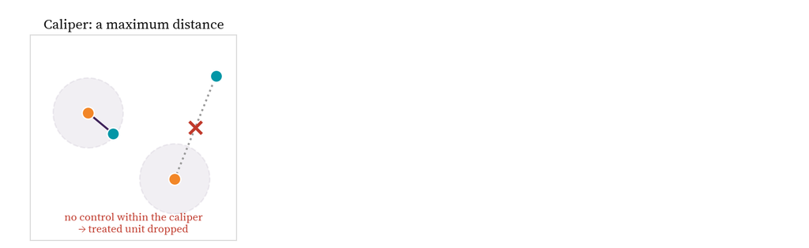

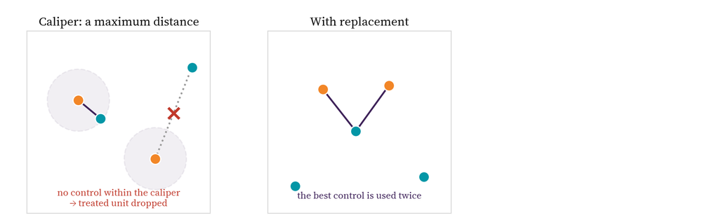

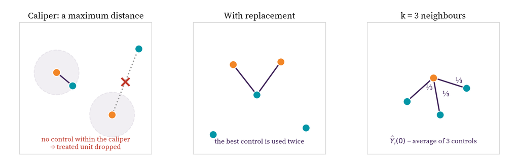

| Choice | Bias | Variance |
| --- | --- | --- |
| Tighter caliper | ↓ (closer matches) | ↑ (fewer treated kept) — and the estimand changes! |
| With replacement | ↓ (always the closest control) | ↑ (few controls used many times) |
| More neighbours $k$ | ↑ (the 3rd closest is worse) | ↓ (average of more controls) |

## Exact matching

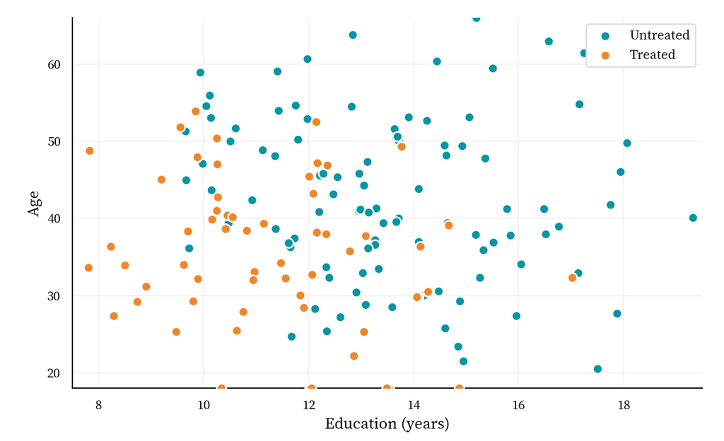

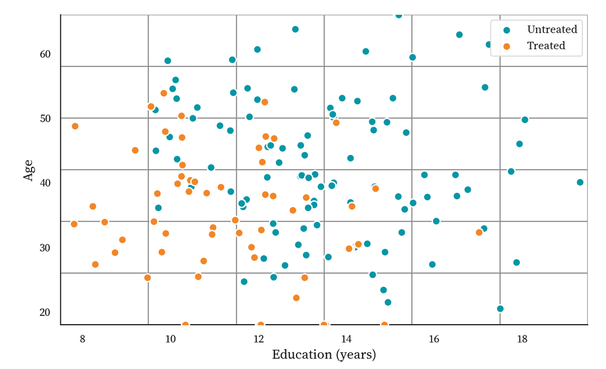

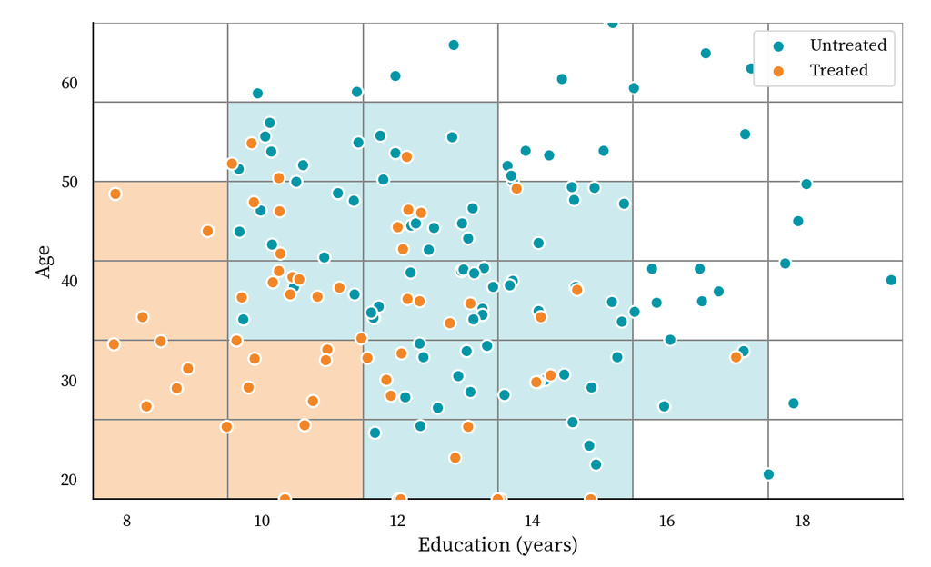

Exact matching

1. Compare a treated unit only with untreated units that have **exactly the same X**.
2. With continuous X, first make groups: 6 education × 6 age groups = **36 cells**. Same cell = same X.
3. treated **and** untreated in the cell: exact matches exist.  
   treated but **no** untreated: 16 of 58 treated have no match and are dropped.

## Exact matching and the curse of dimensionality

[figure not shown]

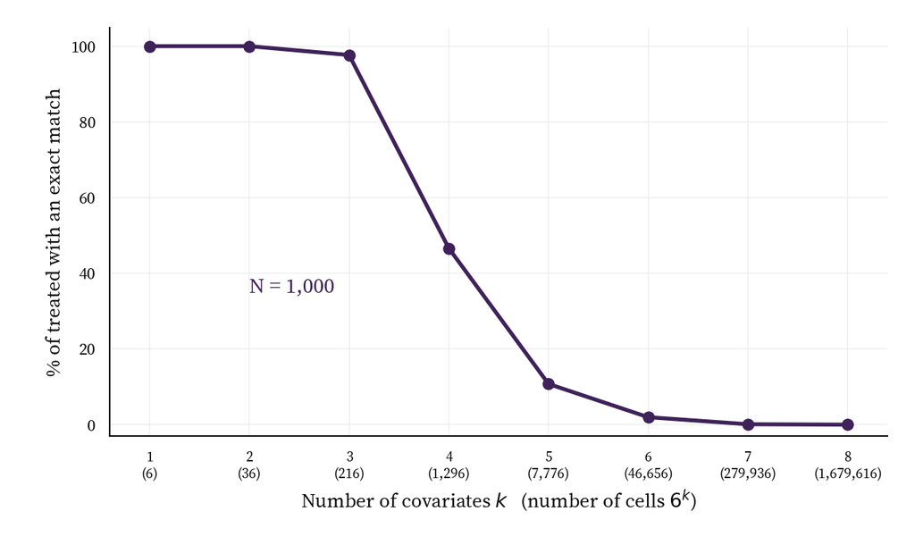

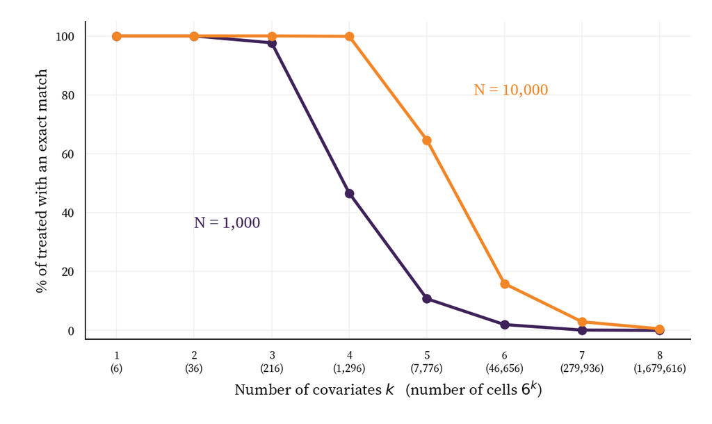

1. Each covariate is cut into **6 groups**, as on the previous slide. A cell is one combination of groups, so with k covariates there are 6 × 6 × … × 6 = **6<sup>k</sup> cells** (in brackets under the axis).
2. Simulation with **N = 1,000** people (20% treated): with 3 covariates 98% of the treated find an exact match; with 5 only 11%; with 8, 0%.
3. **N = 10,000**: ten times more data only delays the problem (65% with 5 covariates, 1% with 8). Cells grow ×6 with each covariate, the data do not: the **curse of dimensionality**.

⇒ We need to summarize all of $X$ in **one number**: the propensity score.

# 3 · The propensity score

## The propensity score

$$p(X) = P(D = 1 \mid X)$$

**Rosenbaum & Rubin (1983).** If the CIA holds given $X$, it also holds given the scalar $p(X)$:

$$\big(Y(1), Y(0)\big) \perp\!\!\!\perp D \mid X \quad\Longrightarrow\quad \big(Y(1), Y(0)\big) \perp\!\!\!\perp D \mid p(X)$$

- Why? $p(X)$ is a **balancing score**: among units with the same $p(X)$, the distribution of $X$ is the same for treated and untreated, $\;D \perp\!\!\!\perp X \mid p(X)$.
- So instead of matching on $k$ covariates, we match on **one** number.
- $p(X)$ is unknown: we **estimate** it, usually with a logit or probit $\;\hat p(X_i) = \Lambda(X_i'\hat\beta)$.

## Matching on the propensity score: 2D → 1D → 2D

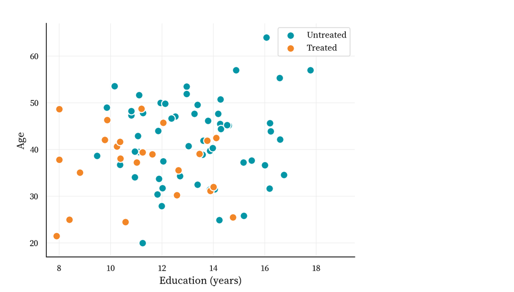

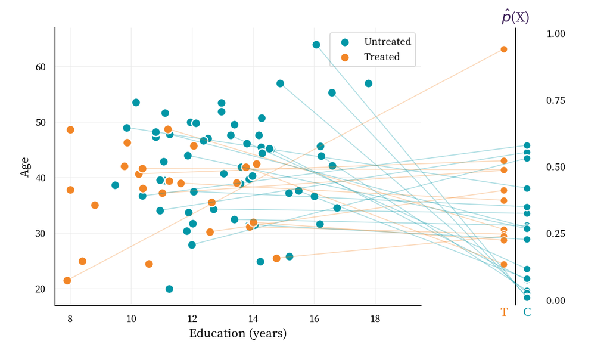

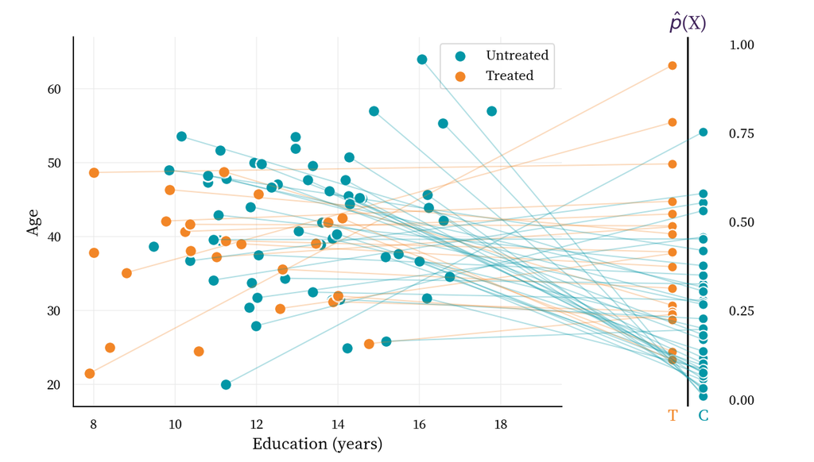

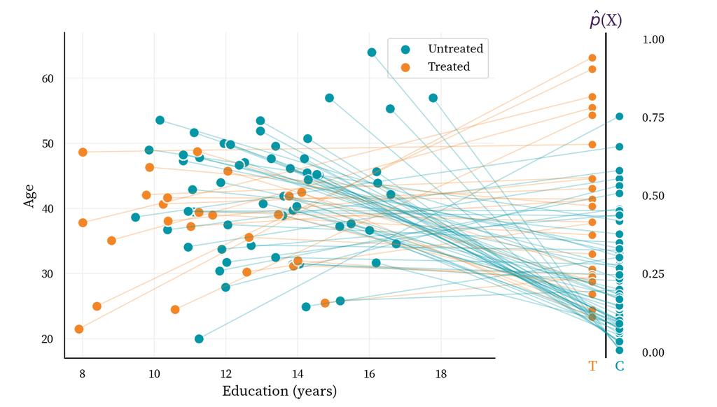

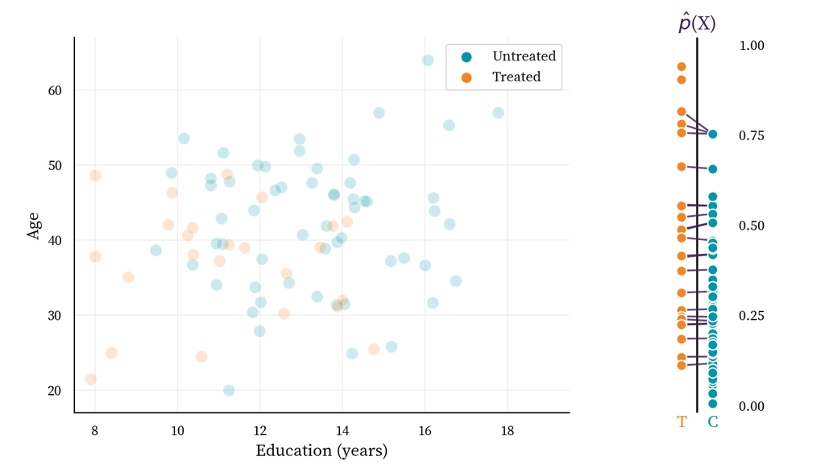

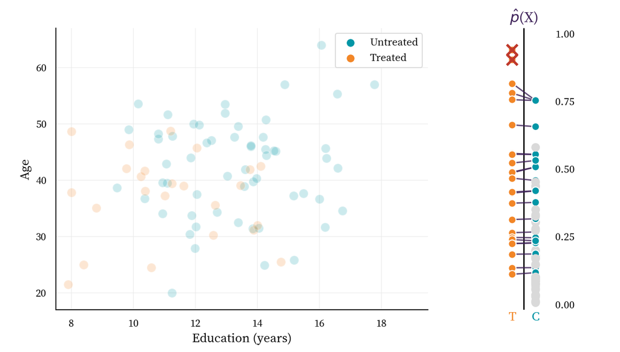

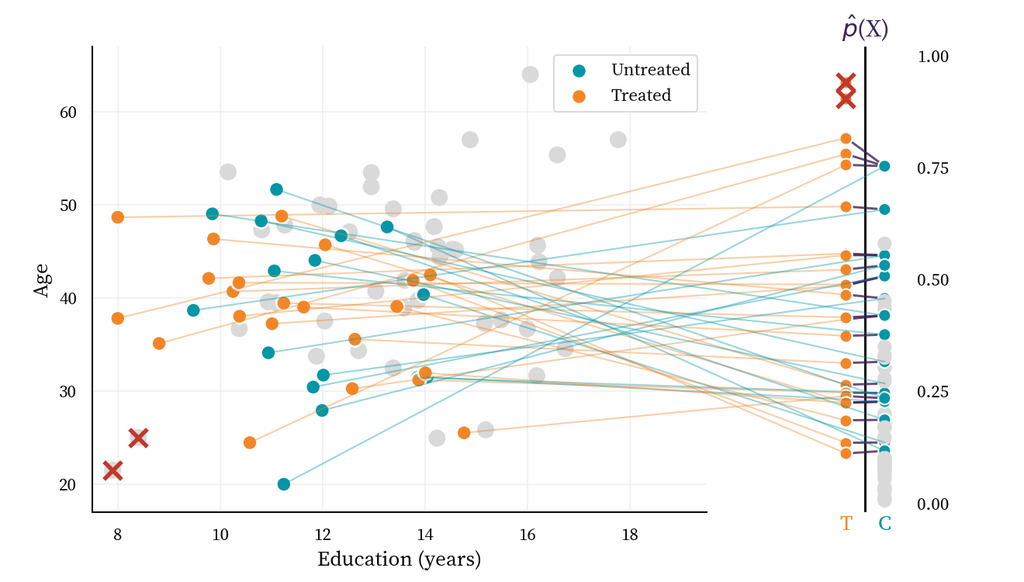

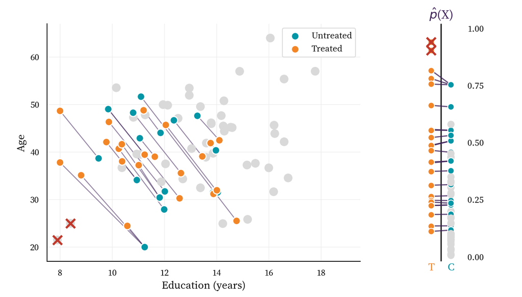

Propensity-score matching

1. Two covariates: treated and untreated differ in X.
2. Estimate \(\hat p(X)\) with a logit and send every unit to its \(\hat p\): **one number** per unit (3 clicks).
3. Match each treated unit to the untreated unit with the closest \(\hat p\) (with replacement, caliper = 0.07).
4. Unused untreated drop out. The 2 treated with \(\hat p\) far above every untreated have no match within the caliper (×): dropped.
5. Send the matched units back to the 2D space.
6. Pairs share \(\hat p\), **not X**. But as groups they now look alike: education 11.5 vs 11.8 (before 11.2 vs 13.3), age 38.3 vs 36.4 (before 37.1 vs 42.2).

Then estimate the ATT on the matched sample exactly as before: $\;\widehat{\text{ATT}} = \frac{1}{N_1}\sum_{i:\,D_i=1}\big(Y_i - Y_{j(i)}\big)$.

## Common support

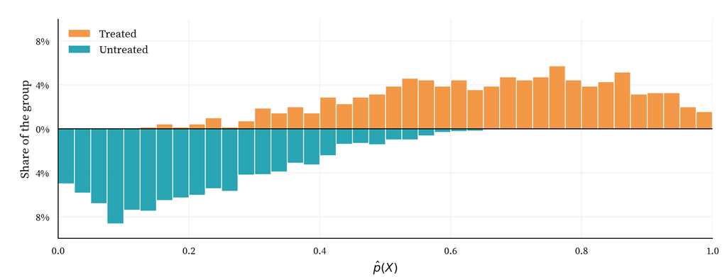

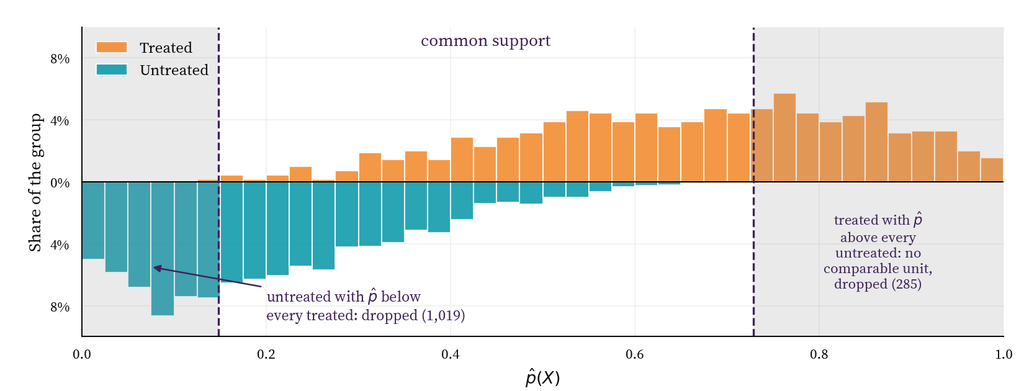

## Checking the balancing property: stratify on $\hat p(X)$

`pscore` (Becker & Ichino, 2002) splits $\hat p$ into **blocks** and tests, inside each block, that treated and untreated have the same mean of every $X$: $\;D \perp\!\!\!\perp X \mid p(X)$.

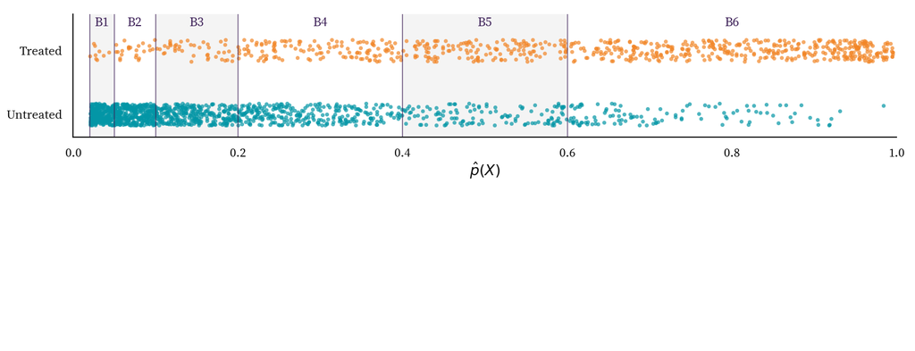

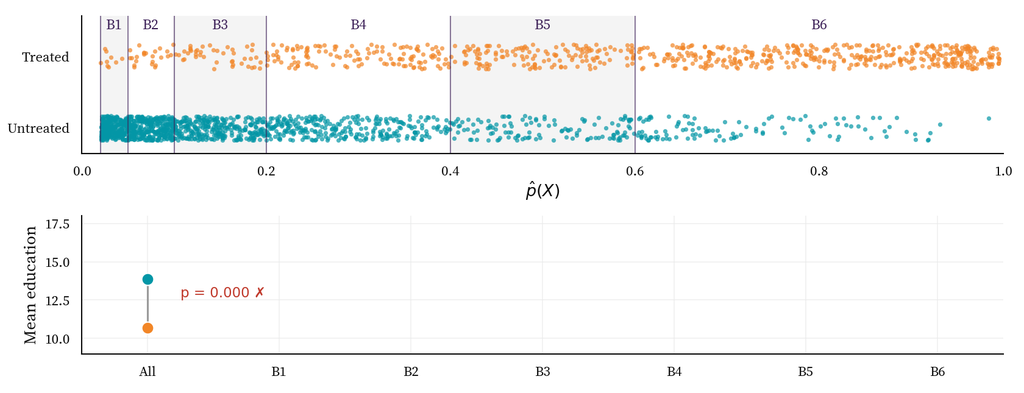

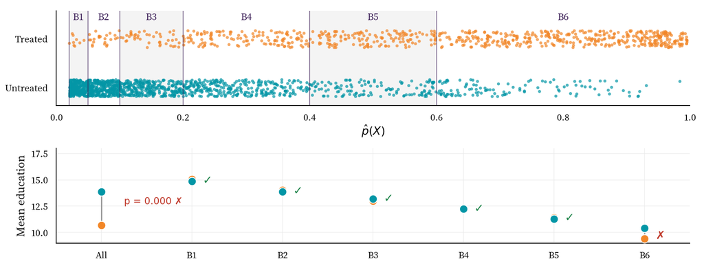

If some $X$ fails in some block, Stata says *“The balancing property is not satisfied — try a different specification”*: add **interactions** or **higher powers** to the logit and run again.